# 454835_homework

Shuai Hu

2024

```r
library(xts)
```

```r
library(ggplot2)
library(utils)
library(rugarch)
library(GAS)
library(ROCR)
library(randomForest)
library(xgboost)
library(scorecard)
library(caret)
library(pROC)
library(tidyverse)
Sys.setlocale("LC_TIME", "English")
```

```
## [1] "English_United States.1252"
```

## Exercise 1.1

Import quotations for any asset of your choice using either provided files or quantmod package from first labs. Then calculate logarithmic returns on that asset and compare Value-at-Risk estimates for 2021 from historical simulation, GARCH models and filtered historical simulation (models should be built on the data prior to 01-01-2021 with moving window method). Does the quality of the models change? Are some approaches much better than the others? What caused such behavior? Plot the VaR estimates together with data.

```r
ukx_index_data <- read.csv("C:\\Users\\Lenovo\\OneDrive\\AAA Warsaw University\\The 3rd semester\\Applied Finance lab\\lab04\\drive-download-20231217T193414Z-001\\ukx.csv", stringsAsFactors = F)
ukx_index_data.xts <- xts(ukx_index_data[,-1],
                      as.Date(ukx_index_data[, 1], "%Y-%m-%d"))
```

```r
p_value <- 0.025
forecast_horizon <- 250
```

```r
ukx_log_returns <- diff(log(ukx_index_data.xts$Close), lag = 1)
ukx_data <- ukx_log_returns["1995/2020"]
```

```r
nrow(ukx_data)
```

```
## [1] 6342
```

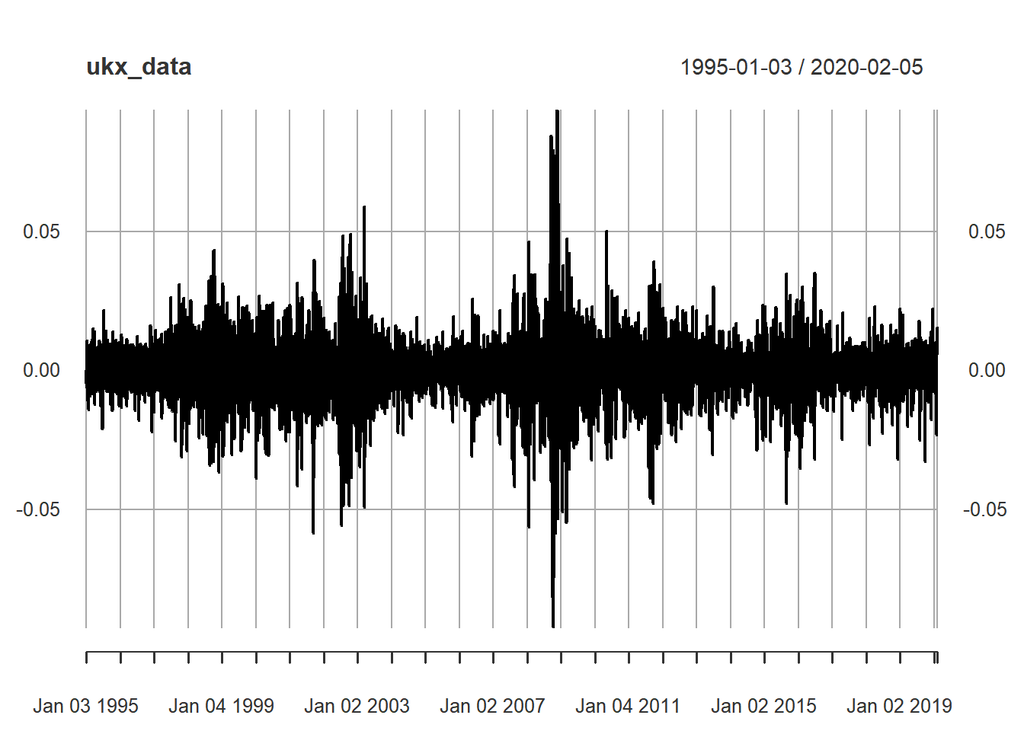

```r
ukx_training_sample_len <- nrow(ukx_data) - forecast_horizon
plot(ukx_data)
```

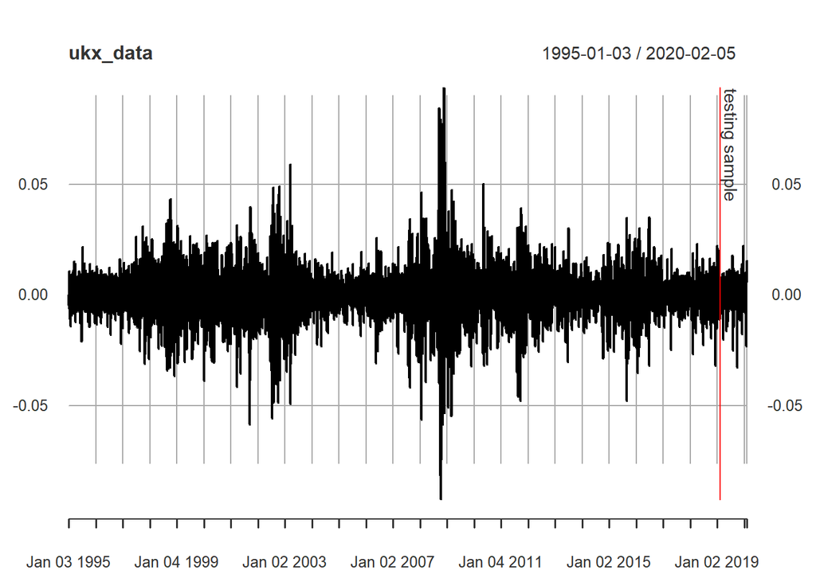

```r
addEventLines(
  events = xts("testing sample", index(ukx_data[nrow(ukx_data) - forecast_horizon + 1])),
  col = "red",
  srt = 270,
  pos = 4
)
```

## Modeling

### Historical simulation

```r
ukx_rollHS <- rollapplyr(ukx_data, ukx_training_sample_len,
                     function(w) {
                       quantile(w, p_value)
                     })
```

```r
ukx_testHS <- tail(lag(ukx_rollHS, 1), 250)
```

```r
specnorm <-
  ugarchspec(
    variance.model = list(model="sGARCH", garchOrder=c(1, 1)),
    mean.model = list(armaOrder = c(0, 0), include.mean = FALSE),
    distribution.model = 'norm'
  )

rollnorm <- ugarchroll(
  specnorm,
  ukx_data,
  n.ahead = 1,
  forecast.length = forecast_horizon,
  refit.every = 1,
  refit.window = 'moving',
  keep.coef = TRUE,
  calculate.VaR = TRUE,
  VaR.alpha = p_value
)
```

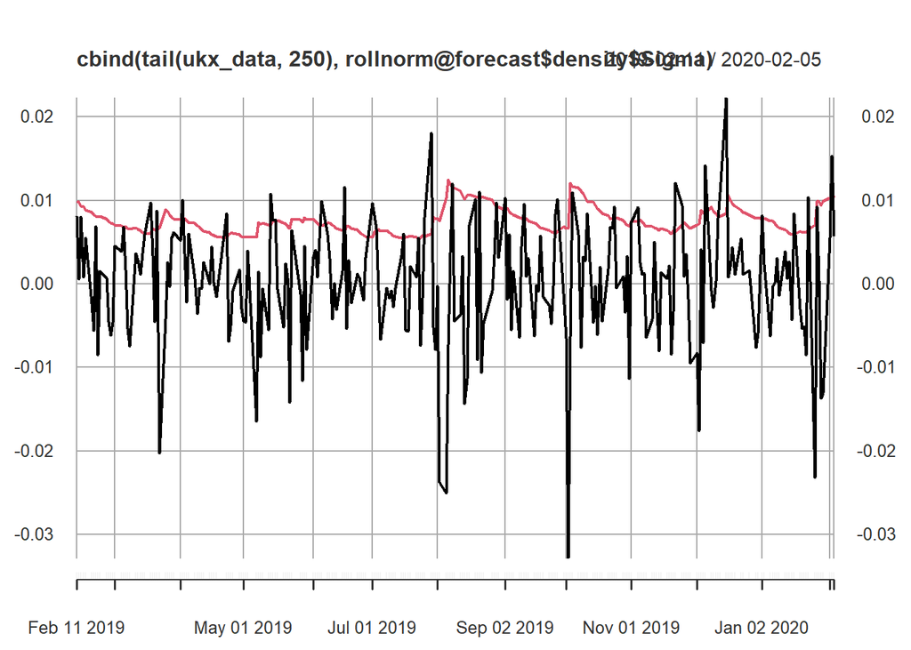

```r
testGarchNORM <- xts(rollnorm@forecast$VaR,
                     as.Date(rownames(rollnorm@forecast$VaR)))[, 1]

plot(cbind(tail(ukx_data, 250), rollnorm@forecast$density$Sigma))
```

### GARCH(1,1) with skewed normal distribution

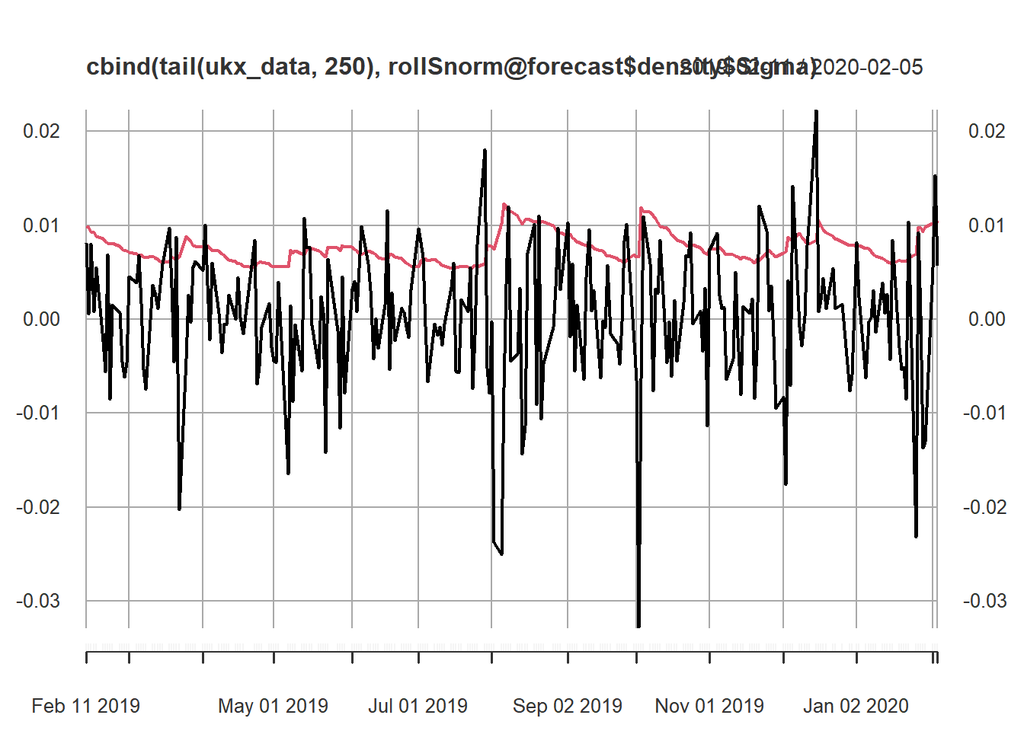

```r
specSnorm <-
  ugarchspec(
    variance.model = list(model="sGARCH", garchOrder=c(1, 1)),
    mean.model = list(armaOrder = c(0, 0), include.mean = FALSE),
    distribution.model = 'snorm'
  )


rollSnorm <-
  ugarchroll(
    specSnorm,
    ukx_data,
    n.ahead = 1,
    forecast.length = forecast_horizon,
    refit.every = 1,
    refit.window = 'moving',
    keep.coef = TRUE,
    calculate.VaR = TRUE,
    VaR.alpha = p_value
  )


testGarchSNORM <- xts(rollSnorm@forecast$VaR,
                      as.Date(rownames(rollSnorm@forecast$VaR)))[, 1]

plot(cbind(tail(ukx_data, 250), rollSnorm@forecast$density$Sigma))
```

### Filtered Historical Simulation (by GARCH(1,1))

```r
rollFHS <- rollapplyr(ukx_data, ukx_training_sample_len,
                      function(ukx_data) {

                        fit <- ugarchfit(specnorm, ukx_data)

                        res <- rugarch::residuals(fit, standardize = T)

                        hat <-
                          sqrt(
                            fit@fit$coef['omega'] + fit@fit$coef['alpha1'] * tail(rugarch::residuals(fit), 1) ^
                              2 + fit@fit$coef['beta1'] * tail(sigma(fit), 1) ^ 2
                          )

                        draw <- sample(res, 20000, replace = T)

                        draw_var <- quantile(draw, p_value)

                        var <- draw_var * as.numeric(hat)
                          return(var)
                      })


testFHS <- tail(lag(rollFHS, 1), 250)
```

```r
testRealised <- tail(ukx_data, 250)
```

```r
var_predictions <- cbind(ukx_testHS,
                         testFHS,
                         testGarchNORM,
                         testGarchSNORM
                         )
colnames(var_predictions) <-
  c("HS","FHS","GARCH Norm", "GARCH SNORM")
```

```r
excess_count <- function(var, true) {

  return(sum(ifelse(coredata(var) > coredata(true), 1, 0)))
}

sapply(var_predictions, excess_count, true = testRealised)
```

```
##          HS         FHS  GARCH Norm GARCH SNORM
##           2           7           8           8
```

```r
VaRTest(p_value, testRealised, ukx_testHS)
```

```
## $expected.exceed
## [1] 6
##
## $actual.exceed
## [1] 2
##
## $uc.H0
## [1] "Correct Exceedances"
##
## $uc.LRstat
## [1] 4.015938
##
## $uc.critical
## [1] 3.841459
##
## $uc.LRp
## [1] 0.04507213
##
## $uc.Decision
## [1] "Reject H0"
##
## $cc.H0
## [1] "Correct Exceedances & Independent"
##
## $cc.LRstat
## [1] 4.048327
##
## $cc.critical
## [1] 5.991465
##
## $cc.LRp
## [1] 0.1321043
##
## $cc.Decision
## [1] "Fail to Reject H0"
```

```r
sapply(var_predictions, function(var) {
  c(
    "Kupiec"=VaRTest(p_value, testRealised, var)$uc.Decision,
    "Christoffersen"=VaRTest(p_value, testRealised, var)$cc.Decision
  )
})
```

```
##                HS                  FHS                 GARCH Norm
## Kupiec         "Reject H0"         "Fail to Reject H0" "Fail to Reject H0"
## Christoffersen "Fail to Reject H0" "Fail to Reject H0" "Fail to Reject H0"
##                GARCH SNORM
## Kupiec         "Fail to Reject H0"
## Christoffersen "Fail to Reject H0"
```

```
## Defaulting to continuous.
```

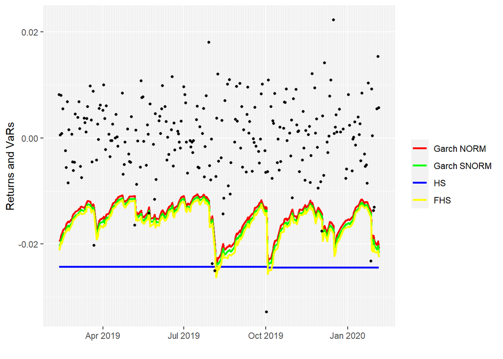

```r
# plot with VaRs
ggplot(testRealised, aes(index(testRealised), indeks)) +
  geom_line(aes(y = testGarchNORM, colour = "Garch NORM"), size = 1) +
  geom_line(aes(y = testGarchSNORM, colour = "Garch SNORM"), size = 1) +
  geom_line(aes(y = ukx_testHS, colour = "HS"), size = 1) +
  geom_line(aes(y = testFHS, colour = "FHS"), size = 1) +
  geom_point(aes(y = testRealised), size = 1) +
  scale_x_date(date_minor_breaks = "1 day") +  scale_colour_manual(
    "",
    breaks = c("Garch NORM", "Garch SNORM", "HS", "FHS"),
    values = c("red", "green", "blue", "yellow")
  ) +
  xlab("") + ylab("Returns and VaRs")
```

The accuracy of VaR estimations can be affected by the model specifications (GARCH) and distributional assumptions (normal vs. skewed normal). The features of the financial asset and the market dynamics during the studied time may have an impact on the models’ performance. The results indicate that the FHS and GARCH SNORM models performed similarly and did not significantly deviate from actual exceedances for the provided data and time period. The HS models, revealed notable distinctions, suggesting that additional improvement or investigation of different modeling strategies may be necessary.

## Exercise 1.2

Load the data for the credit risk applications. Run necessary preprocessing steps. Train logistic regression, random forest and xgboost models. Compare the models performance for AUC. Are the ML models better or worse than logistic regression? Choose a probability of default threshold level for one of the models and justify your selection.

```r
data <- read.csv("C:\\Users\\Lenovo\\OneDrive\\AAA Warsaw University\\The 3rd semester\\Applied Finance lab\\lab04\\drive-download-20231217T193414Z-001\\german_credit.csv", stringsAsFactors = T)
```

```r
glimpse(data)
```

```
## Rows: 1,000
## Columns: 21
## $ default                    <int> 0, 1, 0, 0, 1, 0, 0, 0, 0, 1, 1, 1, 0, 1, 0…
## $ account_check_status       <fct> < 0 DM, 0 <= ... < 200 DM, no checking acco…
## $ duration_in_month          <int> 6, 48, 12, 42, 24, 36, 24, 36, 12, 30, 12, …
## $ credit_history             <fct> critical account/ other credits existing (n…
## $ purpose                    <fct> domestic appliances, domestic appliances, (…
## $ credit_amount              <int> 1169, 5951, 2096, 7882, 4870, 9055, 2835, 6…
## $ savings                    <fct> unknown/ no savings account, ... < 100 DM, …
## $ present_emp_since          <fct> .. >= 7 years, 1 <= ... < 4 years, 4 <= ...…
## $ installment_as_income_perc <int> 4, 2, 2, 2, 3, 2, 3, 2, 2, 4, 3, 3, 1, 4, 2…
## $ personal_status_sex        <fct> male : single, female : divorced/separated/…
## $ other_debtors              <fct> none, none, none, guarantor, none, none, no…
## $ present_res_since          <int> 4, 2, 3, 4, 4, 4, 4, 2, 4, 2, 1, 4, 1, 4, 4…
## $ property                   <fct> "real estate", "real estate", "real estate"…
## $ age                        <int> 67, 22, 49, 45, 53, 35, 53, 35, 61, 28, 25,…
## $ other_installment_plans    <fct> none, none, none, none, none, none, none, n…
## $ housing                    <fct> own, own, own, for free, for free, for free…
## $ credits_this_bank          <int> 2, 1, 1, 1, 2, 1, 1, 1, 1, 2, 1, 1, 1, 2, 1…
## $ job                        <fct> skilled employee / official, skilled employ…
## $ people_under_maintenance   <int> 1, 1, 2, 2, 2, 2, 1, 1, 1, 1, 1, 1, 1, 1, 1…
## $ telephone                  <fct> "yes, registered under the customers name "…
## $ foreign_worker             <fct> yes, yes, yes, yes, yes, yes, yes, yes, yes…
```

```r
data$property <- as.factor(data$property)
data$age <- as.numeric(data$age)
data$credit_amount <- as.double(data$credit_amount)

data$default<- as.factor(data$default)

data$credit_amount <-
  as.factor(ifelse(
    data$credit_amount <= 2500, '0-2500',
    ifelse(data$credit_amount <= 5000, '2501-5000', '5000+')
  ))


data <- data[complete.cases(data),]


set.seed(123456)
d = sort(sample(nrow(data), nrow(data) * .6))
train <- data[d, ]
test <- data[-d, ]
```

```r
model <- default ~ .
```

### logistic regression

```r
model_lr <- glm(model, data = train, family = binomial())



predict <- predict(model_lr, type = 'response', newdata = train)


table(train$default, predict > 0.5)
```

```
##
##     FALSE TRUE
##   0   401   39
##   1    79   81
```

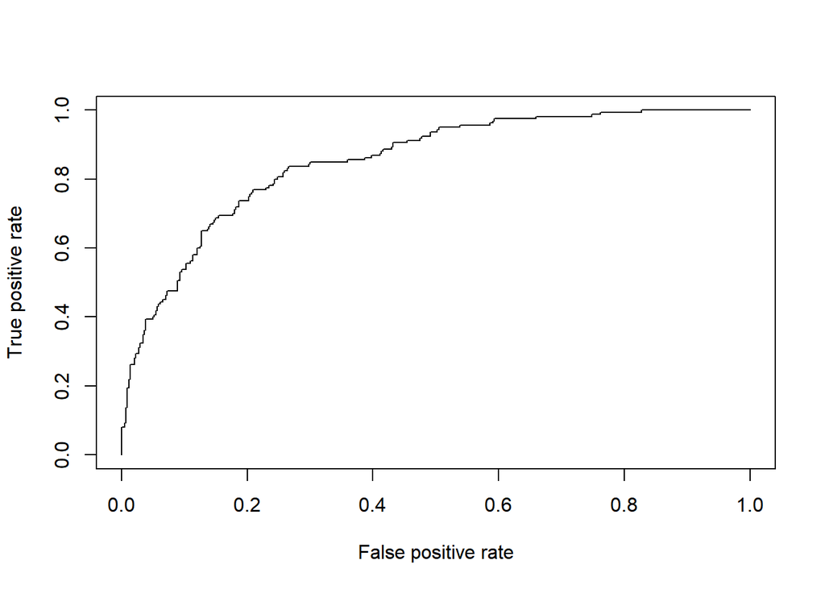

```r
ROCpred <- prediction(predict, train$default)
ROCperf <- performance(ROCpred, 'tpr', 'fpr')
plot(ROCperf)
```

```r
auc <- performance(ROCpred, measure = "auc")
auc <- auc@y.values[[1]]
auc
```

```
## [1] 0.8512216
```

```r
predict <- predict(model_lr, type = 'response', newdata = test)


table(test$default, predict > 0.5)
```

```
##
##     FALSE TRUE
##   0   231   29
##   1    77   63
```

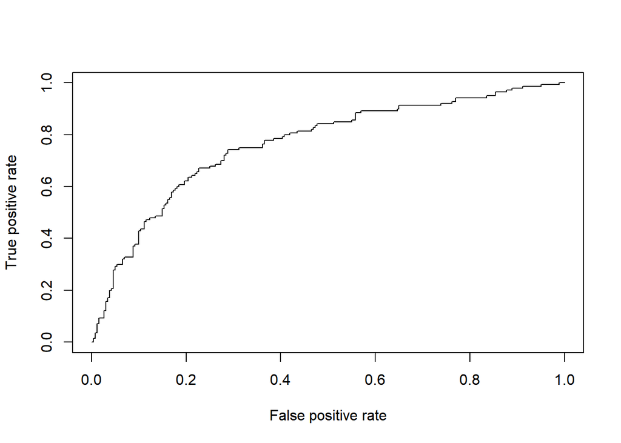

```r
ROCpred <- prediction(predict, test$default)
ROCperf <- performance(ROCpred, 'tpr', 'fpr')
plot(ROCperf)
```

```r
auc <- performance(ROCpred, measure = "auc")
auc <- auc@y.values[[1]]
auc
```

```
## [1] 0.7647253
```

```r
levels(train$default) <- c("level_0", "level_1")
levels(test$default) <- c("level_0", "level_1")
```

### random forest

```r
rf <-
  randomForest(model,
               data = train,
               ntree = 100,
               sampsize = nrow(train),
               mtry = 8,

               nodesize = 100,

               importance = TRUE)
```

```r
pred.train.rf <- predict(rf,
                             train,
                         type = "prob")[, "level_0"]

ROC.train.rf  <- roc(as.numeric(train$default == "level_0"),
                        pred.train.rf)
pred.test.rf  <- predict(rf,
                             test,
                         type = "prob")[, "level_0"]

ROC.test.rf   <- roc(as.numeric(test$default == "level_0"),
                         pred.test.rf)
ROC.test.rf
```

```
##
## Call:
## roc.default(response = as.numeric(test$default == "level_0"),     predictor = pred.test.rf)
##
## Data: pred.test.rf in 140 controls (as.numeric(test$default == "level_0") 0) < 260 cases (as.numeric(test$default == "level_0") 1).
## Area under the curve: 0.76
```

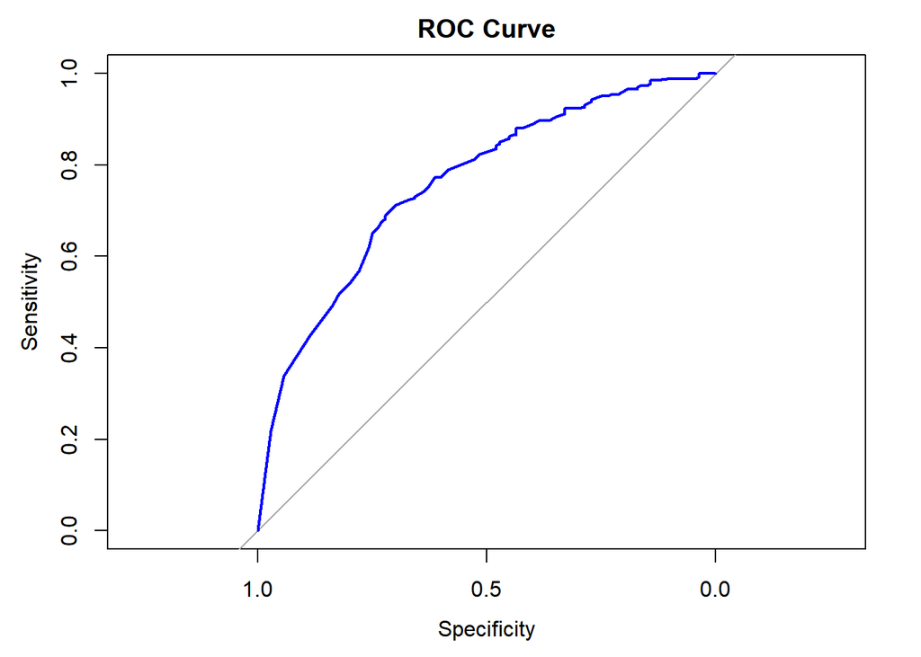

```r
plot(ROC.test.rf, main = "ROC Curve", col = "blue", lwd = 2)
```

### XGboost

```r
parameters_xgb <- expand.grid(nrounds = 110,
                               max_depth = 5,
                               eta = c(0.25),
                               gamma = 0.2,
                               colsample_bytree = 0.2,
                               min_child_weight = 40,
                               subsample = c(0.9))

ctrl_cv5 <- trainControl(method = "cv",
                         number = 5,
                         classProbs = TRUE,
                         summaryFunction = twoClassSummary)


xgb <- train(model,
                     data = train,
                     method = "xgbTree",
                     trControl = ctrl_cv5,
                     tuneGrid  = parameters_xgb)
```

```r
ROC.train <- pROC::roc(train$default,
                       predict(xgb,
                               train, type = "prob")[, "level_0"])
ROC.test  <- pROC::roc(test$default,
                       predict(xgb,
                               test, type = "prob")[, "level_0"])
ROC.test
```

```
##
## Call:
## roc.default(response = test$default, predictor = predict(xgb,     test, type = "prob")[, "level_0"])
##
## Data: predict(xgb, test, type = "prob")[, "level_0"] in 260 controls (test$default level_0) > 140 cases (test$default level_1).
## Area under the curve: 0.6717
```

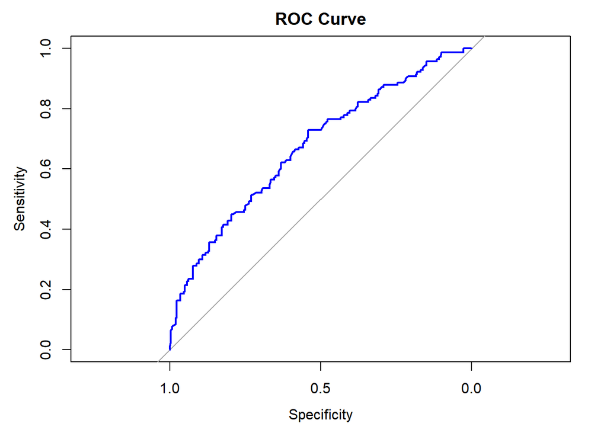

```r
plot(ROC.test, main = "ROC Curve", col = "blue", lwd = 2)
```

```r
# now let's see how that changes on testing sample
predict_LR <- predict(model_lr, type = 'response', newdata = test)

# confusion matrix for training set
table(test$default, predict_LR > 0.5)
```

```
##
##           FALSE TRUE
##   level_0   231   29
##   level_1    77   63
```

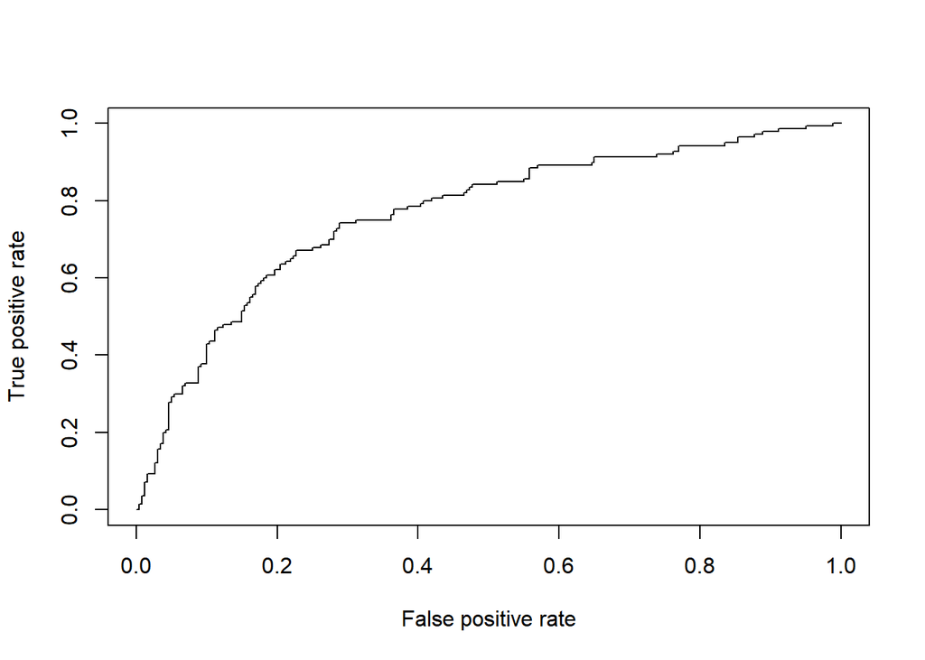

```r
# ROC Curve
ROCpred_t <- prediction(predict_LR, test$default)
ROCperf_t <- performance(ROCpred_t, 'tpr', 'fpr')
plot(ROCperf_t)
```

```r
# AUC value
auc_t <- performance(ROCpred_t, measure = "auc")
auc_t <- auc_t@y.values[[1]]
auc_t
```

```
## [1] 0.7647253
```

```r
# influence of the threshold on the default criterion
table(test$default, predict_LR > 0.2)
```

```
##
##           FALSE TRUE
##   level_0   182   78
##   level_1    36  104
```

```r
table(test$default, predict_LR > 0.7)
```

```
##
##           FALSE TRUE
##   level_0   248   12
##   level_1   101   39
```

```r
best_threshold_index <- which.max(ROCperf_t@y.values[[1]] - ROCperf_t@x.values[[1]])


best_threshold <- ROCperf_t@alpha.values[[1]][best_threshold_index]


print(paste("Best Threshold:", best_threshold))
```

```
## [1] "Best Threshold: 0.204318649337941"
```

Here we use logistic regression and the best Threshold is 0.204318649337941.